# **Proyecto 1 – Predecir la calidad del Vino**

# **Integrantes (2 Personas):**

## **Daniel Santiago Gonzalez Citelly**

## **3. Cree una carpeta para alojar su proyecto, ahí descargue la base winequality-red.csv**

```python
#Importamos las librerias principales.

import pandas as pd
import matplotlib.pyplot as plt
```

```python
#Definición de ruta y cargue de la base de datos.
link = 'https://archive.ics.uci.edu/static/public/186/data.csv'
df = pd.read_csv(link)
print("Se ha creado satisfactoriamente el repositorio!")
```

```
Se ha creado satisfactoriamente el repositorio!
```

## **4. Hagan una celda tipo MarkDown y escriba:**

## **C. Una explicación breve del problema teniendo en cuenta las siguientes fuentes:**

https://archive.ics.uci.edu/dataset/186/wine+quality

https://www.vinhoverde.pt/en/

https://archive.ics.uci.edu/ml/machine-learning-databases/wine-quality/winequality.names

### Explicación del problema planteado:

El Vinho Verde es conocido por su frescura y ligereza, y es producido principalmente en la región del noroeste de Portugal. Es reconocido por su amplia variedad de uvas autóctonas, su carácter refrescante y su versatilidad para maridar con una variedad de platos y de allí su relevancia en el mundo vitivinícola.

Los modelos de regresión lineal y logística se aplicarán para predecir la calidad del vino en base a estas características físico-químicas. En el caso de la regresión lineal, se evaluará el error cuadrático medio y el coeficiente de determinación (R2) para medir la precisión del modelo. Para la regresión logística, se categorizará la calidad del vino en "bueno" o "regular" según un umbral establecido en la variable "quality", y se evaluará la precisión del modelo en base a esta clasificación.

El análisis se complementará con una exploración descriptiva de los datos, el tratamiento de valores nulos si los hubiera, la identificación de variables predictoras y la variable objetivo, así como la evaluación de estadísticos de validación para ambos modelos.

Este ejercicio busca proporcionar una metodología para evaluar la calidad del vino Vinho Verde utilizando modelos predictivos basados en características físico-químicas, lo que puede ser útil para productores, enólogos y entusiastas del vino en la toma de decisiones relacionadas con la producción y comercialización de estos vinos.

información adicional

Los dos conjuntos de datos están relacionados con las variantes tinta y blanca del vino portugués "Vinho Verde". Para más detalles consultar: http://www.vinhoverde.pt/en/ o la referencia [Cortez et al., 2009]. Debido a cuestiones de privacidad y logística, sólo están disponibles variables fisicoquímicas (entradas) y sensoriales (salidas) (por ejemplo, no hay datos sobre tipos de uva, marca de vino, precio de venta del vino, etc.). Estos conjuntos de datos pueden verse como tareas de clasificación o regresión. Las clases están ordenadas y no equilibradas (por ejemplo, hay muchos más vinos normales que excelentes o malos). Se podrían utilizar algoritmos de detección de valores atípicos para detectar los pocos vinos excelentes o malos. Además, no estamos seguros de si todas las variables de entrada son relevantes. Por tanto, podría resultar interesante probar métodos de selección de funciones.

## **5. Ahora en una celda de código cargue la base winequality-red.csv determine la cantidad de variables y registros, indique cuales son numéricas y cualitativas y haga un resumen de esa información.**

### **Información sobre la base**

```python
print("Cantidad de variables:\n", len(df.columns))
```

```
Cantidad de variables:
 13
```

```python
print("Variables numéricas:\n")
print(df.select_dtypes(include=['float64', 'int64']).columns.tolist())
```

```
Variables numéricas:

['fixed_acidity', 'volatile_acidity', 'citric_acid', 'residual_sugar', 'chlorides', 'free_sulfur_dioxide', 'total_sulfur_dioxide', 'density', 'pH', 'sulphates', 'alcohol', 'quality']
```

```python
print("Variables cualitativas:\n")
print(df.select_dtypes(include=['object']).columns.tolist())
```

```
Variables cualitativas:

['color']
```

```python
print(df['color'].unique())
```

```
['red' 'white']
```

```python
print("La información general sobre los datos es:\n")
df.info()
```

```
La información general sobre los datos es:

<class 'pandas.core.frame.DataFrame'>
RangeIndex: 6497 entries, 0 to 6496
Data columns (total 13 columns):
 #   Column                Non-Null Count  Dtype
---  ------                --------------  -----
 0   fixed_acidity         6497 non-null   float64
 1   volatile_acidity      6497 non-null   float64
 2   citric_acid           6497 non-null   float64
 3   residual_sugar        6497 non-null   float64
 4   chlorides             6497 non-null   float64
 5   free_sulfur_dioxide   6497 non-null   float64
 6   total_sulfur_dioxide  6497 non-null   float64
 7   density               6497 non-null   float64
 8   pH                    6497 non-null   float64
 9   sulphates             6497 non-null   float64
 10  alcohol               6497 non-null   float64
 11  quality               6497 non-null   int64
 12  color                 6497 non-null   object
dtypes: float64(11), int64(1), object(1)
memory usage: 660.0+ KB
```

```python
print("El resumen estadístico de los datos numéricos es:")
df.describe()
```

```
El resumen estadístico de los datos numéricos es:
```

|  | fixed_acidity | volatile_acidity | citric_acid | residual_sugar | chlorides | free_sulfur_dioxide | total_sulfur_dioxide | density | pH | sulphates | alcohol | quality |
| --- | --- | --- | --- | --- | --- | --- | --- | --- | --- | --- | --- | --- |
| count | 6497.000000 | 6497.000000 | 6497.000000 | 6497.000000 | 6497.000000 | 6497.000000 | 6497.000000 | 6497.000000 | 6497.000000 | 6497.000000 | 6497.000000 | 6497.000000 |
| mean | 7.215307 | 0.339666 | 0.318633 | 5.443235 | 0.056034 | 30.525319 | 115.744574 | 0.994697 | 3.218501 | 0.531268 | 10.491801 | 5.818378 |
| std | 1.296434 | 0.164636 | 0.145318 | 4.757804 | 0.035034 | 17.749400 | 56.521855 | 0.002999 | 0.160787 | 0.148806 | 1.192712 | 0.873255 |
| min | 3.800000 | 0.080000 | 0.000000 | 0.600000 | 0.009000 | 1.000000 | 6.000000 | 0.987110 | 2.720000 | 0.220000 | 8.000000 | 3.000000 |
| 25% | 6.400000 | 0.230000 | 0.250000 | 1.800000 | 0.038000 | 17.000000 | 77.000000 | 0.992340 | 3.110000 | 0.430000 | 9.500000 | 5.000000 |
| 50% | 7.000000 | 0.290000 | 0.310000 | 3.000000 | 0.047000 | 29.000000 | 118.000000 | 0.994890 | 3.210000 | 0.510000 | 10.300000 | 6.000000 |
| 75% | 7.700000 | 0.400000 | 0.390000 | 8.100000 | 0.065000 | 41.000000 | 156.000000 | 0.996990 | 3.320000 | 0.600000 | 11.300000 | 6.000000 |
| max | 15.900000 | 1.580000 | 1.660000 | 65.800000 | 0.611000 | 289.000000 | 440.000000 | 1.038980 | 4.010000 | 2.000000 | 14.900000 | 9.000000 |

El resumen de la información es:

- Cantidad de variables: 13
- Cantidad de registros o entradas: 6.497

**Variables numéricas:**

```
fixed_acidity
volatile_acidity
citric_acid
residual_sugar
chlorides
free_sulfur_dioxide
total_sulfur_dioxide
density
pH
sulphates
alcohol
quality
```

**Variables cualitativas:**

```
color
```

**Resumen:**

Para las variables numéricas, se proporcionan estadísticas descriptivas que incluyen recuento, media, desviación estándar, valor mínimo, percentiles (25%, 50%, 75%) y valor máximo.

La variable cualitativa 'color' tiene dos categorías: ['red' 'white']

Las variables numéricas representan diversas características de muestras de vino, como la acidez fija, la acidez volátil, el contenido de ácido cítrico, el contenido de azúcar residual, los cloruros, el dióxido de azufre libre, el dióxido de azufre total, la densidad, el pH, los sulfatos, el contenido de alcohol y la calidad del vino.

la calidad del vino es una variable ordinal, con valores discretos entre 3 y 9

## 6. La variable quality es la variable objetivo, con lo consultado anteriormente haga una regresión lineal para predecir quality. Evalue los valores del error cuadrático medio y R2. Haga sus conclusiones, si ve la posibilidad de reentrenar el modelo y mejorar sus resultados hágalo.

```python
from sklearn.model_selection import train_test_split
from sklearn.linear_model import LinearRegression
from sklearn.metrics import mean_squared_error, r2_score

# Separar las características y la variable objetivo
X = df.drop(columns=['quality', 'color'])
y = df['quality']

# Dividir los datos en conjuntos de entrenamiento y prueba
X_train, X_test, y_train, y_test = train_test_split(X, y, test_size=0.2, random_state=42)

# Inicializar y ajustar el modelo de regresión lineal
model = LinearRegression()
model.fit(X_train, y_train)

# Predecir los valores de calidad en los datos de prueba
y_pred = model.predict(X_test)

# Calcular el error cuadrático medio (MSE) y el coeficiente de determinación (R2)
mse = mean_squared_error(y_test, y_pred)
r2 = r2_score(y_test, y_pred)

print("Error Cuadrático Medio (MSE):", mse)
print("Coeficiente de Determinación (R2):", r2)
```

```
Error Cuadrático Medio (MSE): 0.5466964419594438
Coeficiente de Determinación (R2): 0.2597673129771405
```

[figure not shown]

```python
# Gráfica de la regresión lineal
plt.scatter(y_test, y_pred, color='blue')
plt.plot([y_test.min(), y_test.max()], [y_test.min(), y_test.max()], color='red', linestyle='--')
plt.xlabel('Valores reales')
plt.ylabel('Predicciones')
plt.title('Regresión lineal: Valores reales vs Predicciones')
plt.show()
```

- **Error Cuadrático Medio (MSE)** es aproximadamente 0.55, lo que indica que, en promedio, el modelo predice la calidad del vino con un error cuadrático medio de 0.55 puntos en una escala de calidad que va de 0 a 10.
- **Coeficiente de Determinación (R2)** es aproximadamente 0.26, lo que significa que alrededor del 26% de la variabilidad en la calidad del vino se explica por el modelo de regresión lineal utilizado.

Estos valores proporcionan una idea de qué tan bien se ajusta el modelo a los datos. Idealmente, se busca minimizar el MSE y maximizar el R2 para obtener un modelo de regresión lineal más preciso.

Si los valores del MSE son altos y el R2 es bajo, indica que el modelo actual no está capturando adecuadamente la relación entre las variables predictoras y la variable objetivo. En este caso, es necesario reentrenar el modelo.

Esto se puede ver también en la gráfica del modelo de regresión lineal donde cada punto azul representa un par de valores: el valor real (eje X) y la predicción de tu modelo (eje Y). Si un punto se encuentra en la línea roja, significa que la predicción coincide exactamente con el valor real. La línea roja punteada representa la predicción perfecta. Si el modelo fuera 100% preciso, todos los puntos azules estarían sobre esta línea, sin embargo los puntos están dispersos, lo que indica que las predicciones no son muy precisas. Esto es coherente con el valor R2 relativamente bajo de 0.2597, que indica que el modelo solo explica el 25.97% de la variabilidad en los datos.

En conclusión, aunque el modelo de regresión lineal puede capturar parte de la variabilidad en la calidad del vino (26%), el rendimiento del modelo no es muy alto. Por lo cual, se sugiere robustecer el modelo con algoritmos de regresión que puedan capturar mejor las relaciones no lineales entre las características y la calidad del vino.

Para reentrenar y mejorar el modelo de regresión lineal, utilizaremos el algoritmo de aprendizaje automático Random Forest, el cual se basa en la construcción de múltiples árboles de decisión durante el entrenamiento y la combinación de sus predicciones para obtener una predicción más robusta y precisa.

```python
#Algoritmo de aprendizaje RandomForest
from sklearn.ensemble import RandomForestRegressor

# Dividir el conjunto de datos en entrenamiento y prueba
X_train, X_test, y_train, y_test = train_test_split(X, y, test_size=0.2, random_state=42)

# Definir el modelo Random Forest con hiperparámetros predeterminados
rf_model = RandomForestRegressor(n_estimators=100, random_state=42)

# Entrenar el modelo
rf_model.fit(X_train, y_train)

# Predecir en el conjunto de prueba
y_pred_rf = rf_model.predict(X_test)

# Calcular métricas de evaluación
mse_rf = mean_squared_error(y_test, y_pred_rf)
r2_rf = r2_score(y_test, y_pred_rf)

print("Error cuadrático medio (MSE) para Random Forest:", mse_rf)
print("Coeficiente de determinación (R2) para Random Forest:", r2_rf)
```

```
Error cuadrático medio (MSE) para Random Forest: 0.3713522307692308
Coeficiente de determinación (R2) para Random Forest: 0.49718520459177784
```

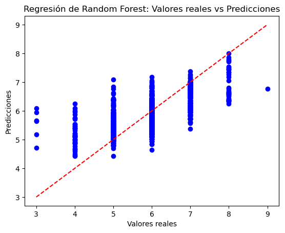

```python
# Gráfica de la regresión de Random Forest
plt.scatter(y_test, y_pred_rf, color='blue')
plt.plot([y_test.min(), y_test.max()], [y_test.min(), y_test.max()], color='red', linestyle='--')
plt.xlabel('Valores reales')
plt.ylabel('Predicciones')
plt.title('Regresión de Random Forest: Valores reales vs Predicciones')
plt.show()
```

Al aplicar el algoritmo de aprendizaje automático Random Forest, se logró mejorar en el desempeño del modelo en comparación con los resultados anteriores, es decir que el error cuadrático medio (MSE) ha disminuido de un valor inicial de 0.54669644195944380 a un valor final de 0.3713522307692308 y el coeficiente de determinación (R2) ha aumentado de un valor inicial de 0.2597673129771405 a un valor final de 0.49718520459177784 , lo que indica una mejor capacidad de predicción del modelo. Esto se puede ver también en la gráfica del modelo entrenado con RandomForest donde al igual que en la anterior gráfica, cada punto azul representa un par de valores: el valor real (eje X) y la predicción del modelo (eje Y). Si un punto se encuentra en la línea roja, significa que la predicción coincide exactamente con el valor real. En este caso, los puntos están agrupados en áreas principales, lo que indica que para esos valores específicos de datos reales, las predicciones son consistentes pero no necesariamente precisas, ya que no siguen la línea roja punteada. Esto es coherente con el valor R2 de 0.4972, que indica que el modelo entrenado explica el 49.72% de la variabilidad en los datos.

## **7. Asumiremos que si quality es mayor o igual a 6 entonces el vino es bueno, en otro caso diremos que tiene calidad regular. Haga una variable nueva con esta condición y llámela categorical_quality. Esta nueva variable será la variable objetivo de nuestra regresión logística.**

```python
# Creamos la variable categorical_quality usando la condición dada
df['categorical_quality'] = df['quality'].apply(lambda x: 'bueno' if x >= 6 else 'regular')
df.head()
```

|  | fixed_acidity | volatile_acidity | citric_acid | residual_sugar | chlorides | free_sulfur_dioxide | total_sulfur_dioxide | density | pH | sulphates | alcohol | quality | color | categorical_quality |
| --- | --- | --- | --- | --- | --- | --- | --- | --- | --- | --- | --- | --- | --- | --- |
| 0 | 7.4 | 0.70 | 0.00 | 1.9 | 0.076 | 11.0 | 34.0 | 0.9978 | 3.51 | 0.56 | 9.4 | 5 | red | regular |
| 1 | 7.8 | 0.88 | 0.00 | 2.6 | 0.098 | 25.0 | 67.0 | 0.9968 | 3.20 | 0.68 | 9.8 | 5 | red | regular |
| 2 | 7.8 | 0.76 | 0.04 | 2.3 | 0.092 | 15.0 | 54.0 | 0.9970 | 3.26 | 0.65 | 9.8 | 5 | red | regular |
| 3 | 11.2 | 0.28 | 0.56 | 1.9 | 0.075 | 17.0 | 60.0 | 0.9980 | 3.16 | 0.58 | 9.8 | 6 | red | bueno |
| 4 | 7.4 | 0.70 | 0.00 | 1.9 | 0.076 | 11.0 | 34.0 | 0.9978 | 3.51 | 0.56 | 9.4 | 5 | red | regular |

Tomando la nueva variable 'categorical_quality' como variable objetivo en la regresión logística, se obtiene el siguiente modelo:

```python
from sklearn.linear_model import LogisticRegression
from sklearn.preprocessing import LabelEncoder, StandardScaler
from sklearn.metrics import accuracy_score

# Convertir la variable objetivo a variables numéricas (0 para regular, 1 para good)
label_encoder = LabelEncoder()
df['target'] = label_encoder.fit_transform(df['categorical_quality'])

# Definir las variables predictoras (X) y la variable objetivo (y)
X = df.drop(columns=['quality', 'color', 'categorical_quality', 'target'])  # Variables predictoras
y = df['target']  # Variable objetivo

# Dividir los datos en conjuntos de entrenamiento y prueba
X_train, X_test, y_train, y_test = train_test_split(X, y, test_size=0.2, random_state=42)

# Escalar los datos
scaler = StandardScaler()
X_train_scaled = scaler.fit_transform(X_train)
X_test_scaled = scaler.transform(X_test)

# Inicializar y ajustar el modelo de regresión logística con datos escalados
logistic_model = LogisticRegression(max_iter=2000)
logistic_model.fit(X_train_scaled, y_train)

# Predecir en el conjunto de prueba
y_pred = logistic_model.predict(X_test_scaled)

# Calcular la precisión del modelo
accuracy = accuracy_score(y_test, y_pred)

print("Precisión del modelo de regresión logística con datos escalados:", accuracy)
```

```
Precisión del modelo de regresión logística con datos escalados: 0.7238461538461538
```

## **8.Haga una partición de la base 80-20 para determinar base de entrenamiento y testeo para la regresión logística. Posteriormente, entrene la regresión logística con la base de entrenamiento.**

Dividimos los datos en conjuntos de entrenamiento y prueba de acuerdo con la proporción 80 de entrenamiento y 20 de prueba

```python
#Definición de ruta y cargue de la base de datos.
link = 'https://archive.ics.uci.edu/static/public/186/data.csv'
df = pd.read_csv(link)
print("Se ha creado satisfactoriamente el repositorio!")
```

```
Se ha creado satisfactoriamente el repositorio!
```

```python
# Creamos la variable categorical_quality usando la condición dada
df['categorical_quality'] = df['quality'].apply(lambda x: 'bueno' if x >= 6 else 'regular')
df.head()
```

|  | fixed_acidity | volatile_acidity | citric_acid | residual_sugar | chlorides | free_sulfur_dioxide | total_sulfur_dioxide | density | pH | sulphates | alcohol | quality | color | categorical_quality |
| --- | --- | --- | --- | --- | --- | --- | --- | --- | --- | --- | --- | --- | --- | --- |
| 0 | 7.4 | 0.70 | 0.00 | 1.9 | 0.076 | 11.0 | 34.0 | 0.9978 | 3.51 | 0.56 | 9.4 | 5 | red | regular |
| 1 | 7.8 | 0.88 | 0.00 | 2.6 | 0.098 | 25.0 | 67.0 | 0.9968 | 3.20 | 0.68 | 9.8 | 5 | red | regular |
| 2 | 7.8 | 0.76 | 0.04 | 2.3 | 0.092 | 15.0 | 54.0 | 0.9970 | 3.26 | 0.65 | 9.8 | 5 | red | regular |
| 3 | 11.2 | 0.28 | 0.56 | 1.9 | 0.075 | 17.0 | 60.0 | 0.9980 | 3.16 | 0.58 | 9.8 | 6 | red | bueno |
| 4 | 7.4 | 0.70 | 0.00 | 1.9 | 0.076 | 11.0 | 34.0 | 0.9978 | 3.51 | 0.56 | 9.4 | 5 | red | regular |

```python
# Dividir los datos en variables predictoras (X) y variable objetivo (y)
X = df.drop(['categorical_quality', 'quality'], axis=1)  # variables predictoras
y = df['categorical_quality']  # variable objetivo
```

Dividimos la base de datos en conjuntos de entrenamiento y prueba en una proporción del 80% para entrenamiento y 20% para pruebas

```python
from sklearn.model_selection import train_test_split
from sklearn.linear_model import LogisticRegression

# Codificar características categóricas utilizando One-Hot Encoding
X = pd.get_dummies(X)

# Dividir la base en entrenamiento y prueba (80-20)
X_train, X_test, y_train, y_test = train_test_split(X, y, test_size=0.2, random_state=42)

# Inicializar y entrenar el modelo de regresión logística
log_reg_model = LogisticRegression(max_iter=2000)
log_reg_model.fit(X_train, y_train)

# Predecir en la base de testeo
y_pred = log_reg_model.predict(X_test)

# Calcular la precisión del modelo
precision = accuracy_score(y_test, y_pred)

print("Precisión del modelo de regresión logística con datos escalados:", precision)

print("Ahora el modelo de regresión logística está entrenado y listo para ser evaluado con los datos de prueba o utilizado para hacer predicciones sobre nuevos datos.")
```

```
Precisión del modelo de regresión logística con datos escalados: 0.73
Ahora el modelo de regresión logística está entrenado y listo para ser evaluado con los datos de prueba o utilizado para hacer predicciones sobre nuevos datos.
```

## **9. Resuma los estadísticos de validación según la implementación en la base de testeo.**

```python
from sklearn.metrics import accuracy_score, precision_score, recall_score, f1_score, confusion_matrix

# Calcular métricas de evaluación
accuracy = accuracy_score(y_test, y_pred)
precision = precision_score(y_test, y_pred, pos_label='bueno') # Teniendo en cuenta One-Hot Encoding 0='Bueno' y 1='Regular'
recall = recall_score(y_test, y_pred, pos_label='bueno')
f1 = f1_score(y_test, y_pred, pos_label='bueno')

# Imprimir las métricas de evaluación
print("Accuracy:", accuracy)
print("Precision:", precision)
print("Recall:", recall)
print("F1 Score:", f1)
```

```
Accuracy: 0.73
Precision: 0.7868663594470046
Recall: 0.8044758539458187
F1 Score: 0.7955736750145603
```

## **10. Saque sus conclusiones, si ve la posibilidad de reentrenar el modelo y mejorar sus resultados hágalo.**

Dado los resultados de las métricas de evaluación para el modelo, podemos concluir:

El modelo tiene una precisión razonable en general, pero aún hay margen de mejora. El recall para los vinos de calidad "bueno" es relativamente alto, lo que sugiere que el modelo es efectivo para identificar esta clase. Sin embargo, la precisión podría mejorarse, especialmente para evitar clasificar incorrectamente los vinos de calidad "regular" como "bueno".

Para mejorar el modelo primero codificamos las variables categóricas en los datos de entrenamiento y prueba utilizando la codificación one-hot. Luego, entrenamos el modelo de regresión logística utilizando GridSearchCV. Finalmente, evaluamos el mejor modelo en el conjunto de prueba y se muestra la precisión

```python
#Definición de ruta y cargue de la base de datos.
link = 'https://archive.ics.uci.edu/static/public/186/data.csv'
df = pd.read_csv(link)
print("Se ha creado satisfactoriamente el repositorio!")
```

```
Se ha creado satisfactoriamente el repositorio!
```

```python
# Creamos la variable categorical_quality usando la condición dada
df['categorical_quality'] = df['quality'].apply(lambda x: 'bueno' if x >= 6 else 'regular')
```

```python
# Dividir la base en entrenamiento y prueba (80-20)
X_train, X_test, y_train, y_test = train_test_split(X, y,test_size=0.2, random_state=42)
```

```python
from sklearn.pipeline import Pipeline
from sklearn.model_selection import GridSearchCV

# Codificar variables categóricas
X_train_encoded = pd.get_dummies(X_train)
X_test_encoded = pd.get_dummies(X_test)

# Definir el pipeline con el escalado de características y la regresión logística
pipeline = Pipeline([
    ('scaler', StandardScaler()),
    ('classifier', LogisticRegression())
])

# Definir los parámetros para la búsqueda de hiperparámetros
param_grid = {
    'classifier__C': [0.001, 0.01, 0.1, 1, 10, 100]
}

# Inicializar GridSearchCV
grid_search = GridSearchCV(pipeline, param_grid, cv=5, scoring='accuracy')

# Entrenar GridSearchCV
grid_search.fit(X_train_encoded, y_train)

# Obtener el mejor modelo
best_model = grid_search.best_estimator_

# Imprimir los mejores parámetros encontrados
print("Mejores parámetros:", grid_search.best_params_)

# Evaluar el mejor modelo en el conjunto de prueba
accuracy = best_model.score(X_test_encoded, y_test)

print("Accuracy del mejor modelo en el conjunto de prueba:", accuracy)
```

```
Mejores parámetros: {'classifier__C': 0.1}
Accuracy del mejor modelo en el conjunto de prueba: 0.7261538461538461
```

El mejor parámetro de regularización C es 0.1, con una precisión del modelo en el conjunto de prueba del 72.62%, lo cual es bastante bueno.

## **11. En un párrafo explique ¿Cuál de los dos modelos fue mejor? Justifique adecuadamente su respuesta.**

Antes de realizar una conclusión sobre cuál de los dos modelos obtiene mejores resultados en la predecicción de la calidad del vino, es importante considerar la naturaleza de la variable objetivo y las métricas de evaluación de cada modelo.

Dicho esto, en el modelo de regresión lineal se utilizó para predecir la calidad del vino como una variable continua, no así en el modelo de regresión logística en el cual aplicamos una clasificación de la calidad del vino en dos categorías: "Bueno" o "Regular".

Dado que, la calidad del vino es una variable ordinal, con valores discretos entre 3 y 9, la aplicación de un modelo de regresión logística para la clasificación resulta más apropiada, pues se ajusta en mejor medida a la naturaleza categórica de la variable objetivo creada (categorical_quality).

Basándonos en los resultados obtenidos de los modelos de regresión lineal, Random Forest y regresión logística, podemos sacar las siguientes conclusiones:

- **Regresión Lineal:**

El modelo presenta un MSE relativamente alto (0.5467) y un R2 bajo (0.2598), indicando dificultades para capturar la relación entre las variables predictoras y la calidad del vino.

Esto sugiere que la simplicidad del modelo lineal puede no ser adecuada para la complejidad de los datos o que las variables predictoras no están suficientemente correlacionadas linealmente con la calidad del vino.

- **Random Forest:**

El modelo de Random Forest muestra una mejora significativa sobre la regresión lineal, con un MSE más bajo (0.3714) y un R2 más alto (0.4972), lo que sugiere una mejor captura de las relaciones no lineales entre las variables predictoras y la calidad del vino. Aunque se logra una mejora, aún existe espacio para mejorar mediante la optimización de hiperparámetros o la exploración de técnicas avanzadas.

- **Regresión Logística:**

- **Regresión logística GridSearchCV:**

Con un parámetro de regularización C de 0.1 y una precisión del modelo en el conjunto de prueba del 72.62%, lo cual es bastante bueno, podemos observar que no difiere en gran medida del modlo de regresión logística inicial.

Aunque la precisión es razonablemente alta, siempre existe la posibilidad de mejorarla mediante la optimización de hiperparámetros, la selección de características más relevantes o la exploración de modelos más avanzados.

Desde la perspectiva de las métricas de evaluación del modelo, se observa que el modelo de regresión logística obtuvo resultados más altos en todas estas métricas en comparación con el modelo de regresión lineal. Por lo tanto, basado en la naturaleza de la variable objetivo y el rendimiento de los modelos en las métricas de evaluación, se puede concluir que el modelo de regresión logística representa un modelo más robusto para la predicción de la calidad del vino en términos de clasificación precisa entre las dos categorías definidas.